# octave_gyakzh

1e) Adja meg a következő polárkoordinátájú pont Descartes-koordinátáit: ($\phi=1.23$; $r=5.1$)! A szög radiánban lett megadva! (2 pont)

```matlab
phi = 1.23;r = 5.1;
[x,y]=pol2cart(phi,r)
```

```
x =  1.7046
y =  4.8067
```

2e) Számolja ki a kovariancia mátrixát az alábbi adatmátrix transzponáltjának! (2 pont)  
$\begin{pmatrix} 1 &3& 3& 4\\ 2 & 3& 5 & 6\\ 1 & 3 & 5 & 9\\ 2 & 4 & 9 & 9 \end{pmatrix}$

```matlab
D = [1 3 3 4;2 3 5 6;1 3 5 9;2 4 9 9]
cov(D')
```

```
D =

   1   3   3   4
   2   3   5   6
   1   3   5   9
   2   4   9   9

ans =

    1.5833    2.0000    3.8333    3.6667
    2.0000    3.3333    6.0000    6.3333
    3.8333    6.0000   11.6667   10.6667
    3.6667    6.3333   10.6667   12.6667
```

3e) Számolja ki az 1000-nél kisebb négyzetszámok összegét Octave-val! Milyen parancsokat használt hozzá? (2 pont)

```matlab
clear
32^2
31^2 # 31 négyzete még 1000 alatt van

#0
x = 1:1:31;
sum_of_squares = sumsq(x)

#1
for i = 1:31 num(i)=i*i; endfor;
#for i = 1:31 num(i)=i**2; endfor;
#for i = 1:31 num(i)=i^2; endfor;
sum_of_squares = sum(num)

#2
for i = 1:31 num(i)=i; endfor;
sum_of_squares = sumsq(num)

#3
sum_of_squares = 0;
#for (i=1:31) sum_of_squares = sum_of_squares + i**2; endfor;
for (i=1:31) sum_of_squares += i**2; endfor;
sum_of_squares

#4
for i = 1:1000 x(i)=i**2; endfor;
sum_of_squares = sum(x(find(x < 1000)))
```

```
ans =  1024
ans =  961
sum_of_squares =  10416
sum_of_squares =  10416
sum_of_squares =  10416
sum_of_squares =  10416
sum_of_squares =  10416
```

$\sum\limits_{k=1}^{n}k^{2}=\frac{n(n+1)(2n+1)}{6}$ (Faulhaber)

```matlab
#5
sum_of_squares = (31*(31+1)*(2*31+1))/6
```

```
sum_of_squares =  10416
```

4e) Határozza meg a hibaterjedés szabályának segítségével az $y=x_{1}\cdot x_{2}-sin(x_{2})$ értékek szórásnégyzetét és vesse össze annak az eredményével, ha közvetlenül az y értékekre számol szórásnégyzetet! (3 pont)

parciális deriváltak: pl. ha $x_{1}$ szerint deriválok, akkor $x_{2}$-t konstansnak tekintem stb.  
$\frac{\partial y}{\partial x_{1}}=x_{2}\quad \frac{\partial y}{\partial x_{2}}=x_{1}-\cos(x_{2})$

```matlab
x1 = [1.84 2.77 1.97 2.59 2.73 2.08 0.12 2.53 3.06 1.45];
x2 = [1.55 3.96 6.00 2.11 2.55 3.59 0.60 3.88 3.44 2.81];
mx1 = mean(x1)
mx2 = mean(x2)
pd = [mx2; mx1 - cos(mx2)];
PD = pd * pd' # 2×1 * 1×2 -> 2×2

CV = cov([x1(:), x2(:)]) # vagy CV = cov([x1',x2'])

CD = PD .* CV; # CD = CV.*PD elemenkénti szorzás kommutatív
sum(sum(CD)) #nemlineáris esetben a gauss hibaterjedés csak egy becslést ad a varianciára

disp("összevetés")
y = x1 .* x2 - sin(x2);
var(y) #pontos variancia x1 x2 értékekből
```

```
mx1 =  2.1140
mx2 =  3.0490
PD =

   9.2964   9.4815
   9.4815   9.6703

CV =

   0.73536   0.61869
   0.61869   2.23410

ans =  40.173
összevetés
ans =  19.432
```

5e) Számolja ki a következő mátrix inverzét, sajátértékeit és sajátvektorait! (2 pont) $\begin{pmatrix}1 &2& 2& 4\\ 5& 3 &5 &6\\ 1& 3& 6& 7\\ 2& 7& 8 &9\end{pmatrix}$

```matlab
A = [1 2 2 4;5 3 5 6;1 3 6 7;2 7 8 9]
[vA,eA] = eig(A);
vA; # sajátvektorok a vA sajátvektor mátrix oszlopaiban
v1 = vA(:,1)
v2 = vA(:,2);
v3 = vA(:,3);
v4 = vA(:,4);
eA; # sajátértékek az eA diagonális sajátértékmátrix főátlójában
eigen_values = diag(eA) # kigyűjti a főátlóban található sajátértékeket
inv(A) # inverz
```

```
A =

   1   2   2   4
   5   3   5   6
   1   3   6   7
   2   7   8   9

v1 =

   0.24981
   0.46699
   0.47603
   0.70208

eigen_values =

   19.7919 +  0.0000i
    1.6837 +  0.0000i
   -1.2378 +  1.5196i
   -1.2378 -  1.5196i

ans =

  -0.031250   0.250000  -0.156250  -0.031250
   0.070313  -0.062500  -0.398438   0.320312
  -0.695313   0.062500   0.273438   0.054688
   0.570312  -0.062500   0.101563  -0.179688
```

6e) Az alábbi $x$ és $y$ mérési eredmények ismeretében illesszen a mért pontokra harmadfokú polinomot, majd számolja ki annak integrálját a $0\leq x\leq2$ intervallumon! (2 pont)

```matlab
x = 0:0.2:2;
y = [1.88 1.65 1.88 2.25 2.17 2.35 3.24 3.48 3.49 4.06 4.13];

p = polyfit(x,y,3); # harmadfokú polinom illesztése
pint = polyint(p); # határozatlan integrál
polyval(pint,2) - polyval(pint,0) # határozott integrál Newton-Leibniz alapján (határozatlan integrál helyettesítési
                                  # értékeinek különbsége a felső és alsó integrálási határoknál
```

```
ans =  5.5116
```

7e) Mi a következő polinom deriváltjának helyettesítési értéke az x=2 helyen? (2 pont) $P(x)=(2x^{7}-x^{6}-x^{3}-x^{2}-12x-6) ∗ (7x^{4}-8^{2}+2x+1)$

```matlab
# * művelet a két polinom konvolúcióját (szorzatát) jelenti
a = [2,-1,0,0,-1,-1,-12,-6];
b = [7,0,-8,2,1];

k = polyder(conv(a,b));
#vagy
[k]=polyder(a,b);

polyval(k,2)

#1sorban
polyval(polyder(conv(a,b)),2)
```

```
ans =  86560
ans =  86560
```

8e) Végezzen Fourier-transzformációt a következő adatokra. A transzformált adatok alapján becsülje meg a $p_{1}-p_{2}$ értékét, ha az eredeti függvény a következő képlettel lett generálva: $f(t)=\sin(p_{1}2\pi t)+\sin(p_{2}2\pi t)+2$. A véges számábrázolás miatt az $F(\nu)$ függvényben az eredeti frekvenciákon kívül más helyeken is található nem nulla érték (zaj). Az eredményt az eredeti adatsor és a már ismert paraméterekkel generált adatsor ábrázolásával grafikonon is ellenőrizheti. (3 pont)

```
ans =  32
ans =  32
```

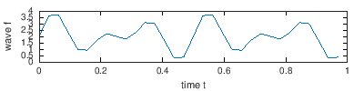

```matlab
# for i=1:32 t(i)=(i-1)*0.03125; endfor;
t = 0:0.03125:0.96875;
f = [2.000,3.631,3.707,2.324,1.000,0.910,1.707,2.217,...
2.000,1.783,2.293,3.090,3.000,1.676,0.293,0.369,...
2.000,3.631,3.707,2.324,1.000,0.910,1.707,2.217,...
2.000,1.783,2.293,3.090,3.000,1.676,0.293,0.369];
length(t),length(f)

figure(1, 'position',[0,0,400,100]);
plot(t,f);xlabel("time t");ylabel("wave f");
```

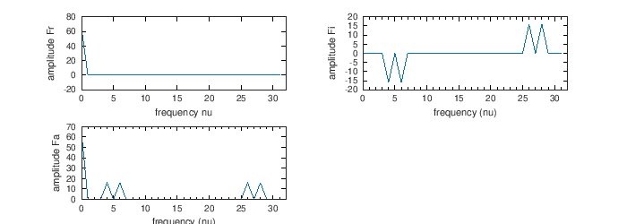

```matlab
dt = 0.03125;
n = length(t);
dnu=1/n/dt;
for i=1:n nu(i)=(i-1)*dnu; endfor;
F=fft(f); # a szinusz hullámot fft-vel fourier transzformáljuk a frekvenciatérbe

#ránézünk az F fourier transzformált Fr valós részére és az Fa abszolút értékére
Fr=real(F);
Fi=imag(F);
Fa=abs(F);

figure(2, 'position',[0,0,700,250]);
subplot (2, 2, 1)
plot (nu,Fr);xlim([0,32]);xlabel("frequency nu");ylabel("amplitude Fr");
subplot (2, 2, 2)
plot (nu,Fi);xlim([0,32]);xlabel("frequency (nu)");ylabel("amplitude Fi");
set (gca, "xminortick", "on")
subplot (2, 2, 3)
plot (nu,Fa);xlim([0,32]);xlabel("frequency (nu)");ylabel("amplitude Fa");
set (gca, "xminortick", "on")
```

```
idx =  1
ans =  64
idx =

    1    5    7   27   29

ans =

   64.000
   15.999
   16.001
   16.001
   15.999

ans =

    0    4    6   26   28

p1 =  4
p2 =  6
```

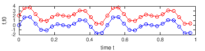

```matlab
# +2 konstans tagból jött a kiugró érték az Fr valós részben
# szinuszos tagok az Fi képzetes részben jelennek meg
idx=find(Fr>10) # konstans tag indexe
F(idx)

# 5 amplitúdónál nagyobb amplitúdó értékek indexe Fa-ból
idx=find(Fa>5) # Fa-ban a 2-2 alacsonyabb amplitudójú (~16) csúcs a két szinuszos tagnak felel meg
F(idx);
Fa'(idx)
nu(idx)

# összetartozó értékek: nu(5) nu(29)
#                       nu(7) nu(27)
p1 = nu(5) # leolvasható Fa és Fi ábrákról is
p2 = nu(7) # leolvasható Fa és Fi ábrákról is


f0 = sin(t*p1*2*pi) + sin(t*p2*2*pi); # +2 konstans tag nélkül

figure(1, 'position',[0,0,400,100]);
plot(t,f,'o-r',t,f0,'o-b');xlabel("time t");ylabel("f,f0");
```

9e) $A$ és $B$ két $3\times3$-as mátrix. Mit jelent a "." az $A.*B$ utasításban? (2 pont)  
A két mátrixot elemenként szorozzuk össze: $a_{ij}\cdot b_{ij}$.

10e) A egy $4\times5$-ös mátrix, milyen változó lesz $v$, ha v=size(A)-val, illetve ha v=size(A)(2)-vel állítja elő? (2 pont)

```matlab
A = randn(4,5);
v = size(A) # kételemű sorvektor, mely megadja az A mátrix sorainak és oszlopainak számát
typeinfo(v) # 1×2 mátrix, azaz 2 elemű sorvektor
v = size(A)(2) # skalár
typeinfo(v)
```

```
v =

   4   5

ans = matrix
v =  5
ans = scalar
```